# Violent Crime vs CCTV in Seoul, 2023

Author

Seoyoung Ko (Luna)

Published

October 1, 2025

> This report examines the relationship between violent crime and CCTV deployment across 25 districts of Seoul, South Korea. In particular, it investigates whether CCTV is more strongly associated with case clearance than with crime prevention.

> CCTV is often framed in crime science as a tool for Situational Crime Prevention, intended to increase risks for offenders by improving surveillance. Within Routine Activity Theory, CCTV can act as a capable guardian, reducing opportunities for crime where offenders and targets converge. At the same time, Deterrence Theory suggests CCTV may be more effective in increasing the certainty detection than in preventing crime directly.

### Executive Summary

> **Caveat**:

> CCTV presence does not directly cause crime reduction; it often reflects reactive deployment in high-crime areas.

> Police-recorded crime and CCTV data from 2023, while population estimate is from 2024.

> Crime and CCTV data were obtained from official Korean government datasets (in Korean). I translated and standardised the variables into English using Excel before analysis. The cleaned dataset is openly available on GitHub [https://github.com/lunasyko/crime_mapping].

## Relationship between Violent crime rate and CCTV density

### Side-by-side map

[interactive chart not shown]

Figure 1: Violent crime vs CCTV density per 10,000 residents (same colour scale). On the left, the map shows CCTV density; on the right, it shows violent crime density

### CCTV-to-crime ratio map

[interactive chart not shown]

Figure 2: CCTV-to-Crime Ratio by district (CCTVs per violent crime).

Figure 2 highlights coverage relative to harm:

- **High ratio (darker blue)**: Districts with more CCTVs per violent crime indicates stronger surveillance coverage relative to crime burden. This may reflect either effective resourcing (more cameras installed) or lower overall crime pressure. Examples include Dobong-gu, Geumcheon-gu, and Yangcheon-gu, where CCTV appears comparatively abundant relative to crime levels.
- **Low ratio (light green - yellow)**: Districts with fewer CCTVs per violent crime suggest weaker coverage relative to crime burden. These are areas where high crime is not matched by equivalent surveillance capacity. For instance, Jung-gu and Yongsan-gu stand out as having surveillance deficits despite heavy crime concentration.

### Scatter plot

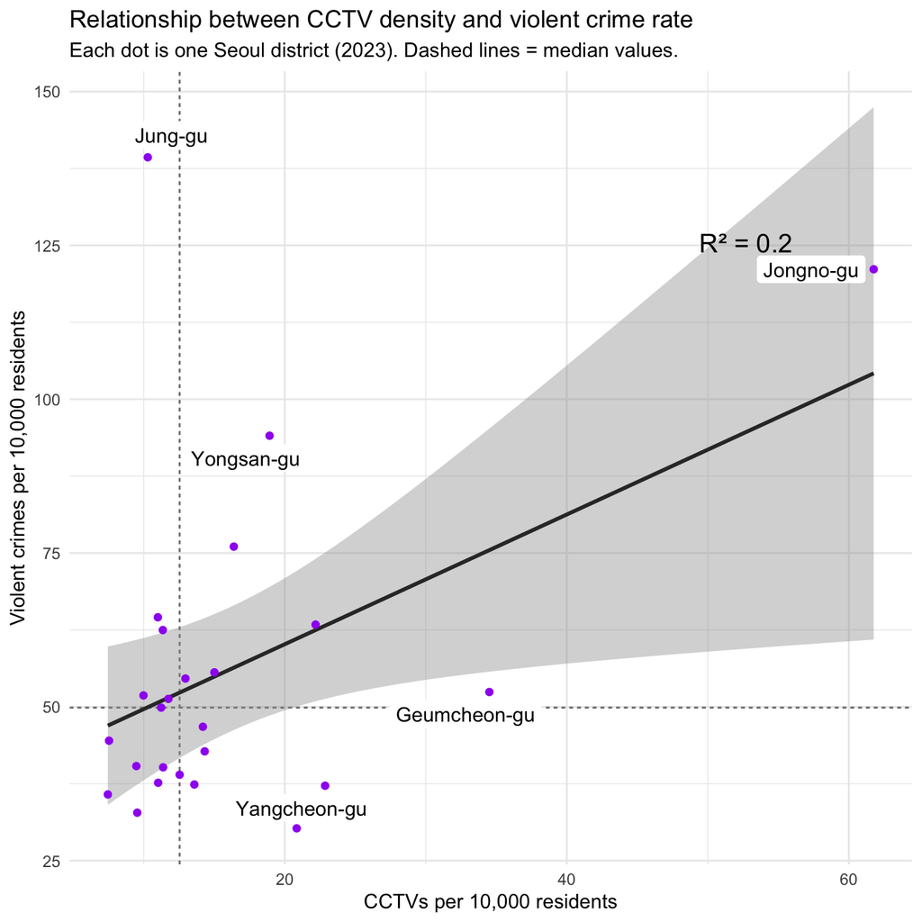

Figure 3: Relationship between CCTV density and violent crime rate

According to Figure 3, there is a **weak positive correlation** (R² ≈ 0.20) between CCTV density and violent crime rate across districts. In other words, districts with more CCTVs often also report higher violent crime rates.

CCTV density only explains about 20% of variation in crime rates; the remaining 80% likely reflects other unmeasured factors, such as population density, socioeconomic variables, and nightlife concentration. This pattern is consistent with Routine Activity Theory, which highlights how crime opportunities emerge where motivated offenders, suitable targets, and limited guardianship converge—conditions often found in busy central districts. While CCTV is designed to act as a guardian, Situational Crime Prevention suggests that surveillance alone may not be sufficient to change offender’s decision-making in high-risk environments.

Outliers, shown with labels, illustrate important mismatches between surveillance and crime (either under-protected high-crime areas or well-protected low-crime areas):

In summary, CCTV appears to be deployed reactively, with more cameras installed where crime is already high. The evidence suggests CCTV is more of a response than a solution to violent crime.

## Relationship between CCTV density and Clearance rate

### Scatter plot

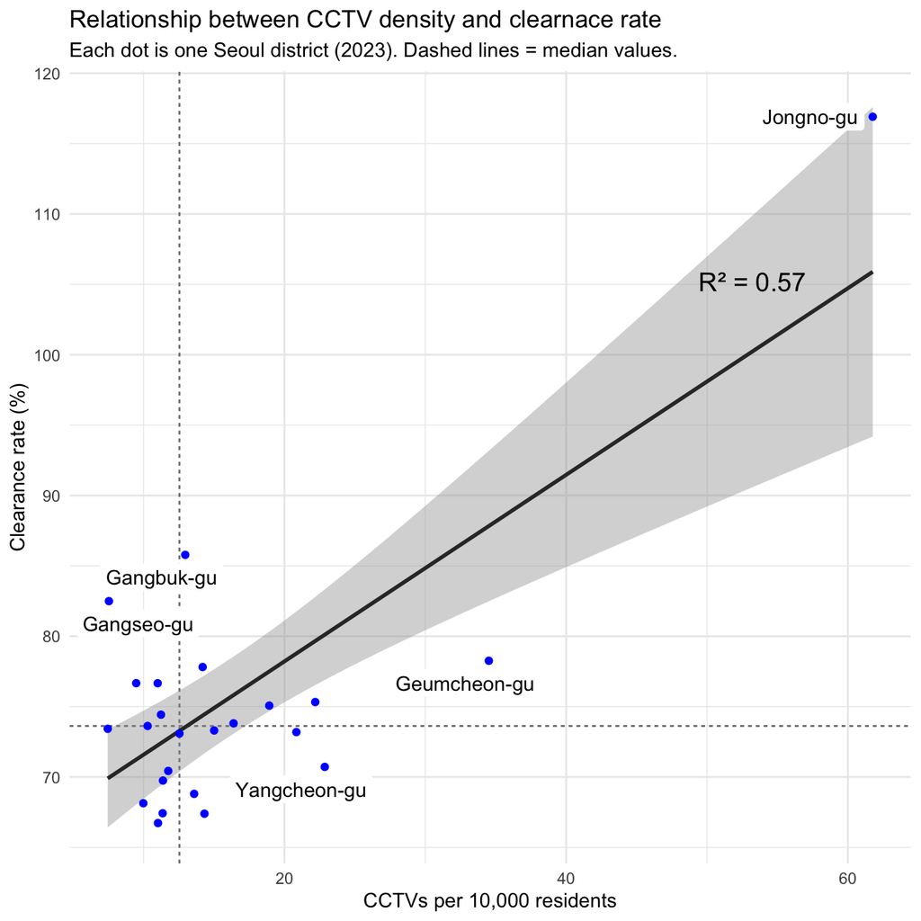

Figure 4: Relationship between CCTV density and clearance rate

Figure 4 shows a **moderate positive relationship** (R² ≈ 0.57) between CCTV density and clearance rate. This means that districts with more CCTV tend to clear more cases. This supports CCTV’s value for investigations, such as evidence and tracing, over prevention.

This pattern aligns with Deterrence Theory, which emphasises the importance of the certainty of detection. Even if CCTV does not prevent incidents, its presence can increase the likelihood of offenders being identified and sanctioned, thereby strengthening responsibility after crimes occur.

In summary, more cameras can help solve crimes, but cameras alone are not enough. It also depends on camera quality, retrieval speed, and how investigators use footage.

## Reference Tables

### Top/Bottom-5 Tables

The top/Bottom-5 tables below highlight the extremes in both violent crime rates and CCTV density across Seoul’s districts. They provide a quick comparison of where crime crime is concentrated and where CCTV coverage is more or least extensive.

Table 1: Districts with the highest violent crime rates in Seoul, 2023 (per 10,000 residents).

**Top 5** by violent crime rate

|  | Violent crimes per 10,000 residents |
| --- | --- |
| Jung-gu | 139.3 |
| Jongno-gu | 121.1 |
| Yongsan-gu | 94.1 |
| Gangnam-gu | 76.0 |
| Yeongdeungpo-gu | 64.6 |

Table 2: Districts with the lowest violent crime rates in Seoul, 2023 (per 10,000 residents).

**Bottom 5** by violent crime rate

|  | Violent crimes per 10,000 residents |
| --- | --- |
| Dobong-gu | 30.3 |
| Seongbuk-gu | 32.8 |
| Gangdong-gu | 35.8 |
| Yangcheon-gu | 37.2 |
| Seodaemun-gu | 37.4 |

Table 3: Districts with the highest CCTV density in Seoul, 2023 (per 10,000 residents).

**Top 5** by CCTV density

|  | CCTVs per 10,000 residents |
| --- | --- |
| Jongno-gu | 61.8 |
| Geumcheon-gu | 34.5 |
| Yangcheon-gu | 22.9 |
| Mapo-gu | 22.2 |
| Dobong-gu | 20.8 |

Table 4: Districts with the lowest CCTV density in Seoul, 2023 (per 10,000 residents).

**Bottom 5** by CCTV density

|  | CCTVs per 10,000 residents |
| --- | --- |
| Gangdong-gu | 7.5 |
| Gangseo-gu | 7.5 |
| Eunpyeong-gu | 9.5 |
| Seongbuk-gu | 9.5 |
| Gwangjin-gu | 10.0 |

### Summary table

Use this as a **reference sheet** for cross-comparing crime burden against resources.

Table 5: Crime, CCTV, clearance, and area data are from 2023. Population estimates are from 2024.

**District-Level Summary**: Crime, CCTV, and Demographics (Seoul)

|  | Population (people) | Area (km^2) | Total Violent Crimes | Violent Crimes per 10,000 residents | Total CCTVs | CCTVs per 10,000 residents | Clearance Rate (%) |
| --- | --- | --- | --- | --- | --- | --- | --- |
| Dobong-gu | 306,032 | 21 | 926 | 30 | 638 | 21 | 73 |
| Dongdaemun-gu | 358,603 | 14 | 1,677 | 47 | 509 | 14 | 78 |
| Dongjak-gu | 387,352 | 16 | 1,459 | 38 | 427 | 11 | 67 |
| Eunpyeong-gu | 465,350 | 30 | 1,879 | 40 | 441 | 9 | 77 |
| Gangbuk-gu | 289,374 | 24 | 1,580 | 55 | 375 | 13 | 86 |
| Gangdong-gu | 481,474 | 25 | 1,722 | 36 | 359 | 7 | 73 |
| Gangnam-gu | 563,215 | 40 | 4,283 | 76 | 923 | 16 | 74 |
| Gangseo-gu | 562,194 | 41 | 2,502 | 45 | 424 | 8 | 82 |
| Geumcheon-gu | 239,070 | 13 | 1,253 | 52 | 825 | 35 | 78 |
| Guro-gu | 411,916 | 20 | 2,113 | 51 | 484 | 12 | 70 |
| Gwanak-gu | 495,620 | 30 | 2,756 | 56 | 744 | 15 | 73 |
| Gwangjin-gu | 348,652 | 17 | 1,808 | 52 | 348 | 10 | 68 |
| Jongno-gu | 149,608 | 24 | 1,812 | 121 | 924 | 62 | 117 |
| Jung-gu | 131,214 | 10 | 1,828 | 139 | 135 | 10 | 74 |
| Jungnang-gu | 385,349 | 18 | 1,922 | 50 | 433 | 11 | 74 |
| Mapo-gu | 372,745 | 24 | 2,362 | 63 | 827 | 22 | 75 |
| Nowon-gu | 496,552 | 35 | 1,935 | 39 | 623 | 13 | 73 |
| Seocho-gu | 413,076 | 47 | 2,581 | 62 | 469 | 11 | 67 |
| Seodaemun-gu | 318,622 | 18 | 1,191 | 37 | 433 | 14 | 69 |
| Seongbuk-gu | 435,037 | 25 | 1,427 | 33 | 415 | 10 | 81 |
| Seongdong-gu | 281,289 | 17 | 1,130 | 40 | 320 | 11 | 70 |
| Songpa-gu | 656,310 | 34 | 2,807 | 43 | 940 | 14 | 67 |
| Yangcheon-gu | 434,351 | 17 | 1,615 | 37 | 993 | 23 | 71 |
| Yeongdeungpo-gu | 397,173 | 25 | 2,564 | 65 | 437 | 11 | 77 |
| Yongsan-gu | 217,194 | 22 | 2,043 | 94 | 411 | 19 | 75 |

# Conclusion

This analysis of Seoul’s 25 districts show that CCTV and violent crime are weakly related. Districts with more cameras often also record more crime, suggesting that cameras are usually installed reactively in response to existing problems rather than acting as a preventive tool.

By contrast, CCTV shows a moderate positive association with case clearance rates. Districts with higher CCTV density tend to resolve more cases. This supports the view that cameras are more effective for investigation and evidence-gathering than for preventing incidents outright.

These findings also align with established crime theories. Routine Activity Theory helps explain why high-crime districts attract reactive CCTV deployment, as central areas create frequent opportunities where offenders and targets converge. Situational Crime Prevention frames CCTV as a situational tool to increase risk, but shows it is most effective when combined with other measures such as lighting, guardianship, or policing presence. Finally, Deterrence Theory explains why CCTV contributes more to case resolution than to prevention, by increasing the perceived certainty of detection rather than removing the opportunity to offend.

Overall, CCTV should be viewed as one element within a broader crime prevention strategy. While valuable for supporting investigations, cameras alone cannot explain or control most variation in crime. To reduce violent crime effectively, CCTV deployment needs to be complemented by social, environmental, policing interventions that address the wider factors driving crime across districts.